# Práctica 2: Algunas aplicaciones con matrices

## Ejercicio 1

Ejecuta las siguientes sentencias y extrae conclusiones sobre el tipo de objeto que devuelven:

```r
A<-matrix(1:9,3,3)
x<-1:3
A%*%x
```

```
     [,1]
[1,]   30
[2,]   36
[3,]   42
```

```r
A%*%t(x)
```

```
Error in A %*% t(x) : non-conformable arguments
```

```r
x%*%A
```

```
     [,1] [,2] [,3]
[1,]   14   32   50
```

```r
t(x)%*%A
```

```
     [,1] [,2] [,3]
[1,]   14   32   50
```

```r
t(x)%*%x
```

```
     [,1]
[1,]   14
```

## Ejercicio 2

Ejecuta las siguientes sentencias en R y formula los sistemas se resuelven en cada caso:

```r
# Sistema 1
solve(2,2)
```

```
[1] 1
```

```r
# Sistema 2
A<-matrix(c(3,1,4,2),2,2)
b<-c(12,8)
solve(A,b)
```

```
[1] -4  6
```

```r
# Sistema 3
solve(A,diag(2))
```

```
     [,1] [,2]
[1,]  1.0 -2.0
[2,] -0.5  1.5
```

```r
solve(A)
```

```
     [,1] [,2]
[1,]  1.0 -2.0
[2,] -0.5  1.5
```

## Ejercicio 3

Crea objetos A (matriz de coe cientes) y b (vector de términos independientes) para resolver en R el sistema anterior. Resuelve el sistema con solve. Después perturba el vector b sumándole 0.05 a cada uno de sus elementos y busca la nueva solución, ¿se parece a la anterior? Repite la operación con un incremento de 0.1. Comenta los resultados.

```r
A<-matrix(c(10,7,8,7,7,5,6,5,8,6,10,9,7,5,9,10),4,4)
b<-c(32,23,33,31)
solve(A,b)
```

```
[1] 1 1 1 1
```

```r
b<-b+0.05
solve(A,b)
```

```
[1] 0.40 2.00 0.75 1.15
```

```r
b<-b+0.05
solve(A,b)
```

```
[1] -0.2  3.0  0.5  1.3
```

## Ejercicio 4

Calcula el número de condición de la matriz A del sistema anterior así como su recíproco. Realiza primero el cálculo con las funciones kappa y rcond y después comprueba que coinciden con su definición (kappa(A) como cociente entre máximo y mínimo autovalor en valor absoluto y rcond(A) como su inversa). Comenta el resultado.

```r
kappa(A)
```

```
[1] 3341.215
```

```r
rcond(A)
```

```
[1] 0.0002228164
```

```r
A.eigenvalues <- eigen(A)$values
A.eigenvalues
```

```
[1] 30.28868535  3.85805746  0.84310715  0.01015005
```

```r
abs(max(A.eigenvalues)/min(A.eigenvalues))
```

```
[1] 2984.093
```

```r
kappa(A, exact=TRUE)  # coincide
```

```
[1] 2984.093
```

## Ejercicio 5

1. Crea la matriz de regresión X y el vector de respuesta y.

```r
n <- 5
set.seed(1)
x <- runif(n)
X <- cbind(rep(1, n), x)
X
```

```
               x
[1,] 1 0.2655087
[2,] 1 0.3721239
[3,] 1 0.5728534
[4,] 1 0.9082078
[5,] 1 0.2016819
```

```r
e <- rnorm(n, sd=0.1)
y <- 1 + x + e
y
```

```
[1] 1.392752 1.413588 1.418858 1.815351 1.172210
```

2. Calcula $(\textbf{X}'\textbf{X})^{-1}$.

```r
solve(t(X)%*%X)
```

```
                     x
   0.8609952 -1.424328
x -1.4243281  3.069176
```

```r
solve(crossprod(X))
```

```
                     x
   0.8609952 -1.424328
x -1.4243281  3.069176
```

3. Usando el resultado anterior calcula βb a partir de la expresión (3).

```r
beta.hat <- solve(crossprod(X))%*%t(X)%*%y
beta.hat
```

```
      [,1]
  1.091479
x 0.756499
```

4. Observa que los datos se han generado verificando exactamente el modelo de regresión lineal (1) con β = (1, 1)′ . ¿Se parece el estimador por mínimos cuadrados que has obtenido a partir de los datos al verdadero β del modelo?

5. Representa el modelo lineal desde el que se han generado los datos escribiendo curve(1+x,-3,3). Después añade los datos que has generado escribiendo points(x,y) y nalmente la estimación del modelo que has calculado, usando de nuevo la función curve con argumento add=TRUE (y si quieres distinto color, por ejemplo rojo, con el argumento col=2).

```r
curve(1+x,-3,3,main='Regresión lineal simple',ylab='y')
points(x,y)
```

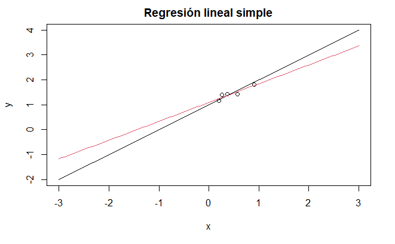

```r
curve(beta.hat[1]+beta.hat[2]*x,add=T,col=2)
```

## Ejercicio 6

Utilizando la misma muestra de n = 5 observaciones que has generado antes calcula el estimador βb usando la descomposición QR. Para ello puedes seguir los siguientes pasos:

1. Obtén la descomposición QR de la matriz X con la función qr.

```r
X.QR <- qr(X)
X.QR
```

```
$qr
                         x
[1,] -2.2360680 -1.0377035
[2,]  0.4472136  0.5708068
[3,]  0.4472136 -0.2980670
[4,]  0.4472136 -0.8855765
[5,]  0.4472136  0.3521906

$rank
[1] 2

$qraux
[1] 1.447214 1.053592

$pivot
[1] 1 2

attr(,"class")
[1] "qr"
```

2. Extrae la matriz Q aplicando la función qr.Q a la descomposición anterior. Observa que la matriz que te devuelve tiene dimensión n × 2 (de hecho solo estas dos columnas son necesarias para los cálculos)

```r
X.Q <- qr.Q(X.QR)
X.Q
```

```
           [,1]       [,2]
[1,] -0.4472136 -0.3478698
[2,] -0.4472136 -0.1610899
[3,] -0.4472136  0.1905693
[4,] -0.4472136  0.7780788
[5,] -0.4472136 -0.4596883
```

3. Calcula el vector Q’y.

```r
b <- t(X.Q)%*%y
b
```

```
           [,1]
[1,] -3.2256439
[2,]  0.4318148
```

4. Extrae la matriz R aplicando la función qr.R a la descomposición anterior. Observa que la matriz que te devuelve tiene dimensión 2 × 2.

```r
X.R <- qr.R(X.QR)
X.R
```

```
                        x
[1,] -2.236068 -1.0377035
[2,]  0.000000  0.5708068
```

5. Resuelve el sistema (4) usando backsolve. Compara la solución con la que obtuviste con la implementación directa.

```r
backsolve(X.R, b)
```

```
         [,1]
[1,] 1.091479
[2,] 0.756499
```

## Ejercicio 7

Considera el sistema Ax = b definido como sigue: Para n = 3 crea la matriz de coeficientes A como un matriz cuadrada A de dimensión n cuya primera columna sea 1, 2, . . . , n, la segunda 1 2 , 2 2 , . . . , n2 , hasta la última 1 n , 2 n , . . . , nn . Crea un vector b como resultado del producto (matricial) de A por un vector de n unos.

```r
library(comprehenr)
n <- 3
A <- matrix(to_vec(for (i in 1:n) c((1:n)^i)), nrow=n, ncol=n)
A
```

```
     [,1] [,2] [,3]
[1,]    1    1    1
[2,]    2    4    8
[3,]    3    9   27
```

```r
b <- A%*%rep(1,n)
b
```

```
     [,1]
[1,]    3
[2,]   14
[3,]   39
```

Con dichos objetos:

1. Resuelve el sistema usando la función solve

```r
x <- solve(A,b)
x
```

```
     [,1]
[1,]    1
[2,]    1
[3,]    1
```

2. Observa que tal y como hemos definido el sistema la solución x es un vector de n unos. Calcula el máximo de las diferencias x − 1 en valor absoluto.

```r
max(abs(x-1))
```

```
[1] 0
```

3. Repite el ejercicio para n = 4, 5, . . . 12. Comenta en cada caso las di cultades del problema en relación a la condición de la matriz de coe cientes.

```r
A <- function(n) matrix(to_vec(for (i in 1:n) (1:n)^i), nrow=n, ncol=n)

for (n in 3:12) {
  A.n <- A(n)
  b.n <- A(n)%*%rep(1, n)
  x.n <- solve(A.n, b.n)
  x.n.maxdiff <- max(abs(x.n-1))
  A.n.rcond <- rcond(A.n)
  print(paste("n=", n, ", x.maxdiff=", x.n.maxdiff, ", A.n.rcond=", A.n.rcond, sep=""))
}
```

```
[1] "n=3, x.maxdiff=0, A.n.rcond=0.00462962962962963"
[1] "n=4, x.maxdiff=0, A.n.rcond=0.000282485875706215"
[1] "n=5, x.maxdiff=2.03415062571821e-12, A.n.rcond=1.12994350282488e-05"
[1] "n=6, x.maxdiff=7.33213489922946e-12, A.n.rcond=4.25353628372841e-07"
[1] "n=7, x.maxdiff=1.12031628418663e-09, A.n.rcond=1.19017467955664e-08"
[1] "n=8, x.maxdiff=5.1078501428492e-09, A.n.rcond=3.21516414214204e-10"
[1] "n=9, x.maxdiff=1.89685563900532e-06, A.n.rcond=6.90966310945938e-12"
[1] "n=10, x.maxdiff=2.69938518471236e-06, A.n.rcond=1.45128908433245e-13"
[1] "n=11, x.maxdiff=0.00343270278765018, A.n.rcond=2.53053974756804e-15"
```

```
Error in solve.default(A.n, b.n) :
  system is computationally singular: reciprocal condition number = 4.34177e-17
```